# Project DATA 606 Data Proposal

Guibril Ramde

2026-04-12

### Data Preparation

```r
# load data
library(tidyverse)
library(janitor)
data_url <- "https://raw.githubusercontent.com/japhet125/Project606/refs/heads/main/lifestyle_weight_tracker.csv"
load_data <- read_csv(data_url)

clean_data <- load_data |>
  clean_names()


clean_data2 <- clean_data |>
  filter(
    calories_consumed > 0,
    protein_g > 0,
    carbs_g > 0,
    fat_g > 0
  ) |>
  drop_na()
clean_data2 <- clean_data2 |>
  mutate(
    height_m = height_cm / 100,
    bmi = current_weight_kg / (height_m^2)
  )

clean_data2 |>
  group_by(workout_intensity) |>
  summarise(
    mean_weight_change = mean(weight_change),
    sd_weight_change = sd(weight_change),
    n = n()
  )

glimpse(clean_data2)
dim(clean_data2)
```

[output not shown]

### Research question

**You should phrase your research question in a way that matches up with the scope of inference your dataset allows for.**

Answer: My research question is: Which lifestyle factors (calorie intake, sleep, stress, caffeine, physical activity, and workout intensity) are significantly associated with weight change?

### Cases

**What are the cases, and how many are there?** Answer:The cases are the individual observations (rows) in the dataset, where each row represents one tracked lifestyle and weight record. There are 55,000 initialy but after cleaning and removing NA values we have 52,236 cases in the dataset.

### Data collection

**Describe the method of data collection.**

Answer: This dataset was obtained from Kaggle as a secondary data source. The file was downloaded as a CSV and then loaded into R using a GitHub raw link. Based on the dataset description, it appears to contain recorded lifestyle and biometric variables related to weight tracking. However, the original data collection and sampling procedures are not fully documented, so the results should be interpreted with caution.

### Type of study

**What type of study is this (observational/experiment)?** Answer: This is an observational study because the dataset records lifestyle and health-related variables without assigning treatments or manipulating conditions.

### Data Source

**If you collected the data, state self-collected. If not, provide a citation/link.**

Answer: Lifestyle Weight Tracker Dataset. The link:https://www.kaggle.com/datasets/waddahali/lifestyle-weight-tracker

### Describe your variables?

**If you are are running a regression or similar model, which one is your dependent variable?** Answer: The response variable is `weight_change`, which is a numerical (continuous) variable representing the change in weight over time.

### Relevant summary statistics

**Provide summary statistics for each the variables. Also include appropriate visualizations related to your research question (e.g. scatter plot, boxplots, etc). This step requires the use of R, hence a code chunk is provided below. Insert more code chunks as needed.**

```r
  summary(clean_data2)
```

```
##     user_id           age          gender            height_cm
##  Min.   :100.0   Min.   :18.0   Length:52236       Min.   :126.2
##  1st Qu.:225.0   1st Qu.:29.0   Class :character   1st Qu.:163.3
##  Median :351.0   Median :41.0   Mode  :character   Median :170.0
##  Mean   :349.7   Mean   :40.9                      Mean   :170.0
##  3rd Qu.:474.0   3rd Qu.:53.0                      3rd Qu.:176.7
##  Max.   :599.0   Max.   :64.0                      Max.   :213.8
##  initial_weight_kg  stress_level     sleep_hours      caffeine_mg
##  Min.   : 85.00    Min.   : 1.000   Min.   : 3.000   Min.   :  0.0
##  1st Qu.: 99.98    1st Qu.: 3.000   1st Qu.: 5.615   1st Qu.:181.8
##  Median :115.02    Median : 6.000   Median : 6.664   Median :260.7
##  Mean   :114.98    Mean   : 5.527   Mean   : 6.670   Mean   :261.1
##  3rd Qu.:129.88    3rd Qu.: 8.000   3rd Qu.: 7.720   3rd Qu.:339.2
##  Max.   :145.00    Max.   :10.000   Max.   :11.000   Max.   :740.2
##  calories_consumed    protein_g        carbs_g          fat_g
##  Min.   :   9.507   Min.   :  0.6   Min.   :  1.1   Min.   :  0.30
##  1st Qu.:1693.714   1st Qu.:105.9   1st Qu.:190.5   1st Qu.: 56.50
##  Median :2095.506   Median :131.0   Median :235.7   Median : 69.90
##  Mean   :2098.324   Mean   :131.1   Mean   :236.1   Mean   : 69.94
##  3rd Qu.:2501.900   3rd Qu.:156.4   3rd Qu.:281.5   3rd Qu.: 83.40
##  Max.   :4874.404   Max.   :304.7   Max.   :548.4   Max.   :162.50
##      steps      workout_type       workout_intensity     temp_c
##  Min.   :7632   Length:52236       Min.   : 0.000    Min.   :-6.076
##  1st Qu.:7939   Class :character   1st Qu.: 0.000    1st Qu.:19.609
##  Median :7999   Mode  :character   Median : 0.000    Median :24.995
##  Mean   :8000                      Mean   : 3.501    Mean   :25.002
##  3rd Qu.:8060                      3rd Qu.: 7.000    3rd Qu.:30.421
##  Max.   :8365                      Max.   :10.000    Max.   :58.914
##  weight_change      current_weight_kg    height_m          bmi
##  Min.   :-0.22776   Min.   : 85.33    Min.   :1.262   Min.   : 21.97
##  1st Qu.: 0.09637   1st Qu.:109.44    1st Qu.:1.633   1st Qu.: 37.33
##  Median : 0.16860   Median :124.52    Median :1.700   Median : 42.99
##  Mean   : 0.16867   Mean   :124.46    Mean   :1.700   Mean   : 43.54
##  3rd Qu.: 0.24129   3rd Qu.:139.32    3rd Qu.:1.767   3rd Qu.: 49.02
##  Max.   : 0.59371   Max.   :291.84    Max.   :2.138   Max.   :109.52
```

Interpretation: Some variables contain unrealistic negative values and missing values, indicating potential data quality issues which we cleaned in the data preparation before analysis.

**Outliers**

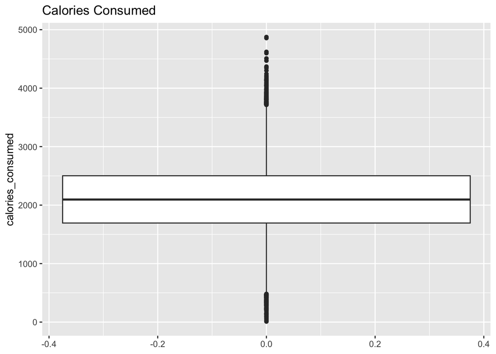

```r
ggplot(clean_data2, aes(y = calories_consumed)) +
  geom_boxplot() +
  labs(title = "Calories Consumed")
```

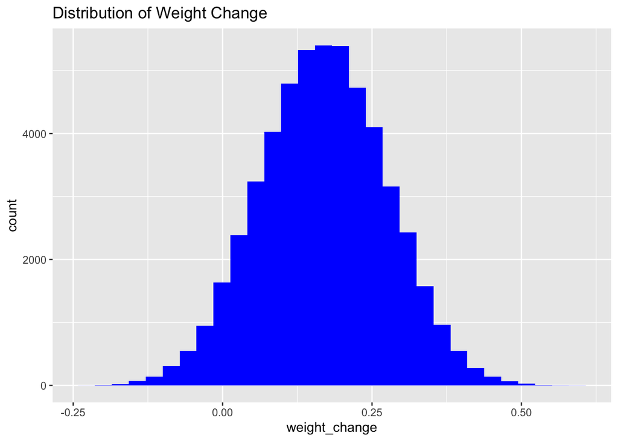

```r
ggplot(clean_data2, aes(x = weight_change)) +
  geom_histogram(bins = 30, fill = "blue") +
  labs(title = "Distribution of Weight Change")
```

Interpretation: the distribution of weight change appears approximately symmetric and bell-shaped, we have a normal distribution.

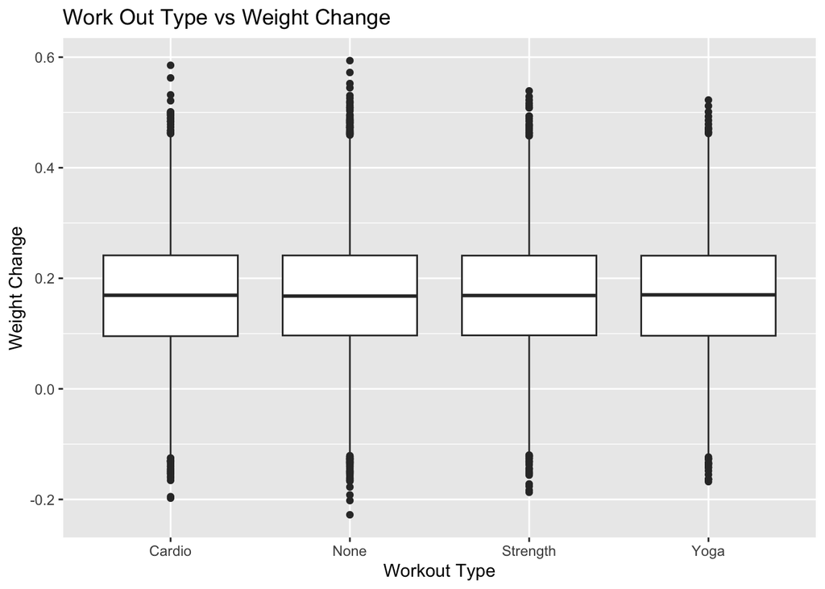

```r
ggplot(clean_data2, aes(x = workout_type, y = weight_change)) +
  geom_boxplot() +
  labs(
    title = "Work Out Type vs Weight Change",
    x = "Workout Type",
    y = "Weight Change"
  )
```

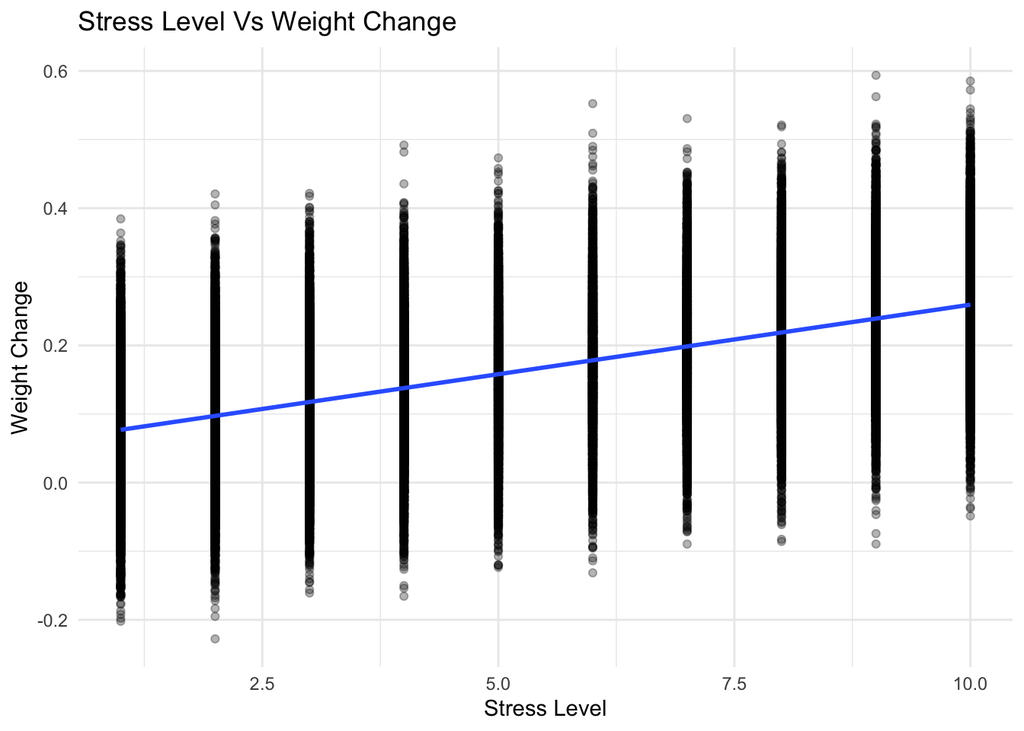

```r
ggplot(clean_data2, aes(x = stress_level, y = weight_change)) +
  geom_point(alpha = 0.3) +
  geom_smooth(method = "lm", se = FALSE) +
  labs(
    title = "Stress Level Vs Weight Change",
    x = "Stress Level",
    y = "Weight Change"
  ) +
  theme_minimal()
```

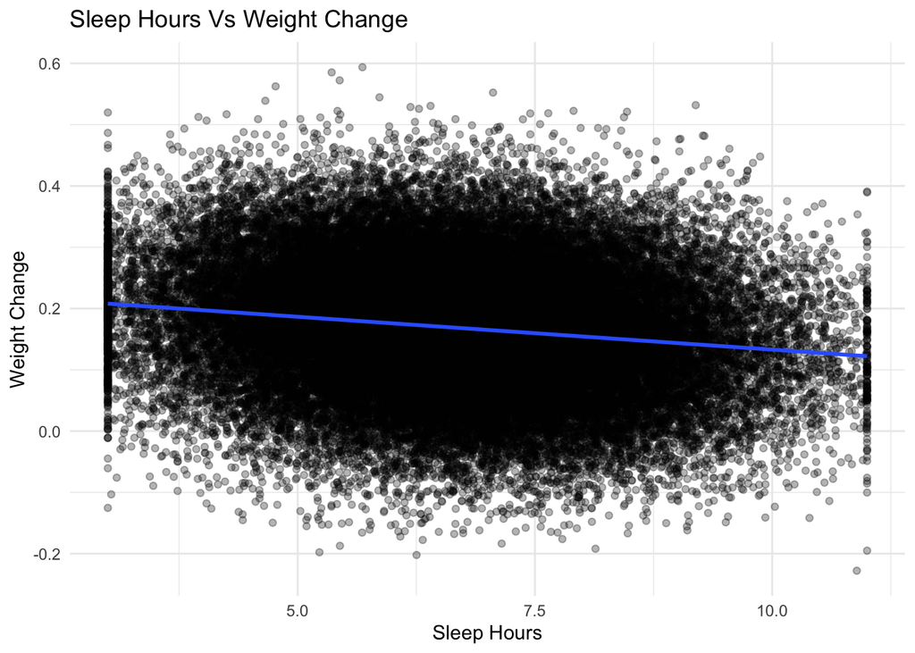

```r
ggplot(clean_data2, aes(x = sleep_hours, y = weight_change)) +
  geom_point(alpha = 0.3) +
  geom_smooth(method = "lm", se = FALSE) +
  labs(
    title = "Sleep Hours Vs Weight Change",
    x = "Sleep Hours",
    y = "Weight Change"
  ) +
  theme_minimal()
```